# 1.2. Python Basics

Module M-227-04: Programming for Data Analytics

Instructor: prof. Dmitry Pavlyuk

## Note: Intendation matters!

```python
if (True):
    print("Hello")
# Working!
```

```
Hello
```

```python
if (True):
print("Hello")
# Intendation error
```

```
  Input In [2]
    print("Hello")
    ^
IndentationError: expected an indented block
```

## Variables

- Variable is a reference to an object in memory

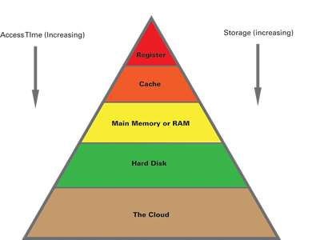

- You can assign (bind) variable to any object at any time
- The same object can be assigned to several variables

```python
a = "dmitry"
b = a
a = a.capitalize()
print(f"a= {a}")
print(f"b= {b}")
```

```
a= Dmitry
b= dmitry
```

```python
a = [1,2,3]
b = a
a.append(4)
print(f"a= {a}")
print(f"b= {b}")
```

```
a= [1, 2, 3, 4]
b= [1, 2, 3, 4]
```

- In Python there is no tehnical problem to assign a variable to an object of different type

```python
a = "Dmitry"
print(f"a= {a}")
a = 10
print(f"a= {a}")
```

```
a= Dmitry
a= 10
```

## Python objects

```python
int_object = 3 #Integer object
string_object = "Content" # String object
print("Type of int_object:", type(int_object))
print("Type of string_object:", type(string_object))
print("Propery bit_length of int_object:", int_object.bit_length)
print("Method upper() of string_object:", string_object.upper())
```

```
Type of int_object: <class 'int'>
Type of string_object: <class 'str'>
Propery bit_length of int_object: <built-in method bit_length of int object at 0x000001F32F996970>
Method upper() of string_object: CONTENT
```

### Mutable and immutable objects

Mutability means an object's ability to change. An immutable object cannot change, but a mutable object can.

For example, a list is mutable, but a string is not. In other words, you can freely change the elements of a list, but not the characters of a string.

```python
print(string_object[0])
string_object[0] = "A"
# Error!
```

```
C
```

```
---------------------------------------------------------------------------
TypeError                                 Traceback (most recent call last)
Input In [7], in <cell line: 2>()
      1 print(string_object[0])
----> 2 string_object[0] = "A"

TypeError: 'str' object does not support item assignment
```

```python
a = [1,2,3]
b = a
a.append(4)
print(f"a= {a}")
print(f"b= {b}")
```

```
a= [1, 2, 3, 4]
b= [1, 2, 3, 4]
```

```python
a = "dmitry"
b = a
a = a.capitalize()
print(f"a= {a}")
print(f"b= {b}")
```

```
a= Dmitry
b= dmitry
```

### Date and time

- The built-in Python datetime module provides datetime, date, and time types (the datetime type combines the information stored in date and time and is the most commonly used)

```python
import datetime as dt

print(dt.date.today())
print(dt.datetime.now())
print(dt.datetime.now().strftime("%d %B %Y %H:%M"))

start = dt.date(2022, 9, 1)
print(start)
print("Full days from the semester start:", (dt.date.today()-start).days)
```

```
2022-09-26
2022-09-26 09:28:39.680667
26 September 2022 09:28
2022-09-01
Full days from the semester start: 25
```

## Functions

- You call **functions** using parentheses and passing zero or more arguments
- Functions themselves are also the object

```python
# Length of the string object
print(len(string_object))

# The third power of the int object
print(pow(int_object, 3))
```

```
7
27
```

- You can define your own function:

```python
def plusone(x):
    return(x+1)


print(plusone(10))
```

```
11
```

## Modules

- Modules are files with Python definitions (e.g., functions) and statements
- Modules should be imported before usage
- You can import the complete module or just a specific function

```python
import math
print(math.factorial(3))
```

```
6
```

- You can import the complete module or just a specific function

```python
from math import factorial
print(factorial(3))
```

```
6
```

- You can organise your own functions in a module (.py file)